# Maize Analysis English

## **Exploratory Data Analysis**

```r
library(summarytools)
dfSummary(data_milho, na.col = F, valid.col = F)
```

```
## Data Frame Summary
## data_milho
## Dimensions: 566 x 9
## Duplicates: 1
##
## ----------------------------------------------------------------------------------------
## No   Variable    Stats / Values              Freqs (% of Valid)    Graph
## ---- ----------- --------------------------- --------------------- ---------------------
## 1    CME         Mean (sd) : 15 (2.1)        103 distinct values             :
##      [numeric]   min < med < max:                                            :
##                  7 < 15 < 22                                               . : .
##                  IQR (CV) : 2.1 (0.1)                                    . : : :
##                                                                      . . : : : : :
##
## 2    NTF         Mean (sd) : 10.2 (1.5)      56 distinct values            :
##      [numeric]   min < med < max:                                          : .
##                  5 < 10 < 14                                             . : : .
##                  IQR (CV) : 2 (0.1)                                    . : : : :
##                                                                      . : : : : : :
##
## 3    ARF         Mean (sd) : 115.2 (28)      241 distinct values           :
##      [numeric]   min < med < max:                                          : :
##                  30 < 114.4 < 189                                        : : : :
##                  IQR (CV) : 38.9 (0.2)                                 . : : : :
##                                                                      . : : : : : .
##
## 4    ALP         Mean (sd) : 208 (39.7)      264 distinct values             : .
##      [numeric]   min < med < max:                                            : :
##                  92 < 215.5 < 313                                        .   : :
##                  IQR (CV) : 55 (0.2)                                   . : : : : :
##                                                                    . . : : : : : : . .
##
## 5    PMG         Mean (sd) : 302.5 (60.8)    118 distinct values           :
##      [numeric]   min < med < max:                                        : :
##                  112 < 310 < 525                                       . : : .
##                  IQR (CV) : 77 (0.2)                                   : : : :
##                                                                      . : : : : .
##
## 6    ALC         Mean (sd) : 404.2 (268.5)   155 distinct values   :
##      [numeric]   min < med < max:                                  :     : .
##                  5 < 400 < 1150                                    : . : : : .
##                  IQR (CV) : 407.5 (0.7)                            : : : : : : :
##                                                                    : : : : : : : : . .
##
## 7    CDE         1. White                    148 (26.1%)           IIIII
##      [factor]    2. Cream                    108 (19.1%)           III
##                  3. Light-yellow              94 (16.6%)           III
##                  4. Yellow                   194 (34.3%)           IIIIII
##                  5. Orange                    22 ( 3.9%)
##
## 8    NTN         Mean (sd) : 9.6 (1.5)       47 distinct values              :
##      [numeric]   min < med < max:                                          : : :
##                  4 < 10 < 13                                             . : : :
##                  IQR (CV) : 2 (0.2)                                      : : : : :
##                                                                      . . : : : : : .
##
## 9    FAS         1. Absent                   491 (86.7%)           IIIIIIIIIIIIIIIII
##      [factor]    2. Present                   75 (13.3%)           II
## ----------------------------------------------------------------------------------------
```

The descriptive statistics for the descriptors used are shown above. Appealing to the Central Limit Theorem, we will assume normality of the distributions.

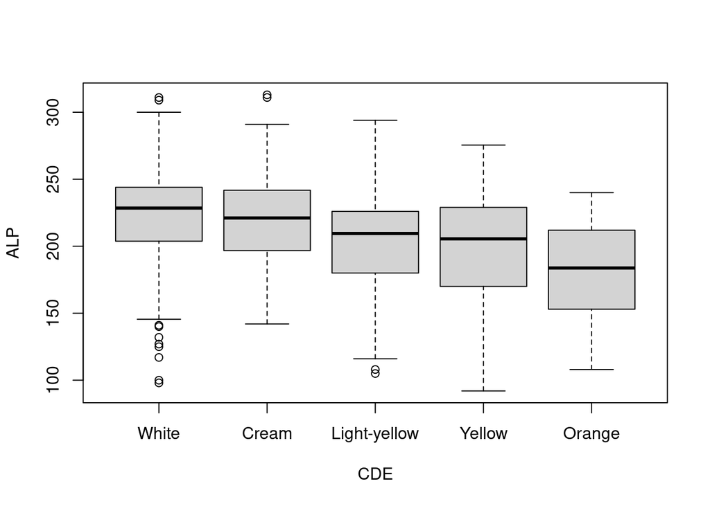

```r
boxplot(ALP~CDE, data = data_milho)
```

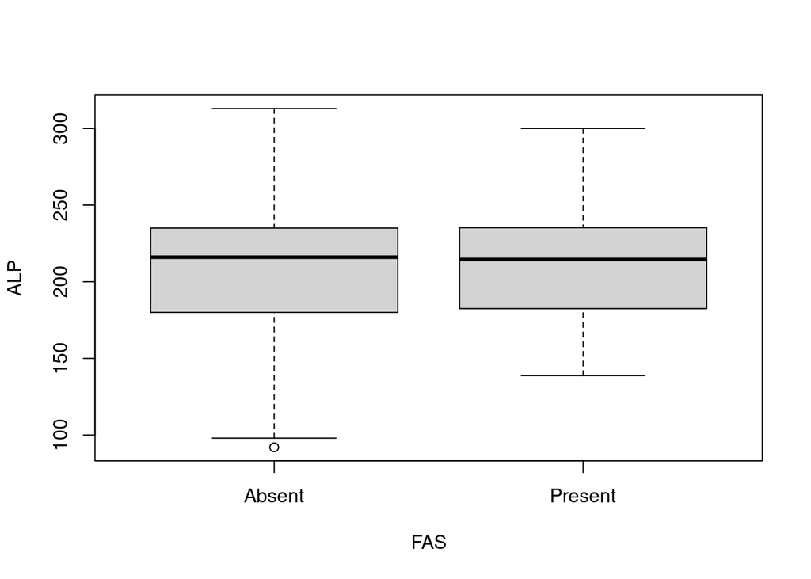

```r
boxplot(ALP~FAS, data = data_milho)
```

```r
#ANOVA analysis between the dependent variable and the categorical variable CDE
#Verify homogeneity of variances
fligner.test(ALP~CDE, data = data_milho)
```

```
##
##  Fligner-Killeen test of homogeneity of variances
##
## data:  ALP by CDE
## Fligner-Killeen:med chi-squared = 4.9117, df = 4, p-value = 0.2965
```

```r
#Assuming normality
model = aov(ALP~CDE, data = data_milho)
summary(model)
```

```
##              Df Sum Sq Mean Sq F value   Pr(>F)
## CDE           4  66381   16595    11.3 7.93e-09 ***
## Residuals   561 823721    1468
## ---
## Signif. codes:  0 '***' 0.001 '**' 0.01 '*' 0.05 '.' 0.1 ' ' 1
```

```r
TukeyHSD(model)
```

```
##   Tukey multiple comparisons of means
##     95% family-wise confidence level
##
## Fit: aov(formula = ALP ~ CDE, data = data_milho)
##
## $CDE
##                           diff       lwr        upr     p adj
## Cream-White          -3.694645 -16.96579   9.576498 0.9413324
## Light-yellow-White  -19.989779 -33.82047  -6.159085 0.0008179
## Yellow-White        -21.281367 -32.72628  -9.836457 0.0000049
## Orange-White        -38.352641 -62.31410 -14.391179 0.0001375
## Light-yellow-Cream  -16.295134 -31.08727  -1.502997 0.0224832
## Yellow-Cream        -17.586722 -30.17661  -4.996836 0.0013770
## Orange-Cream        -34.657997 -59.18698 -10.129015 0.0011609
## Yellow-Light-yellow  -1.291588 -14.46998  11.886806 0.9988623
## Orange-Light-yellow -18.362863 -43.19904   6.473316 0.2560756
## Orange-Yellow       -17.071275 -40.66224   6.519691 0.2769280
```

```r
#ANOVA analysis between the dependent variable and the categorical variable FAS
#Verify homogeneity of variances
fligner.test(ALP~FAS, data = data_milho)
```

```
##
##  Fligner-Killeen test of homogeneity of variances
##
## data:  ALP by FAS
## Fligner-Killeen:med chi-squared = 1.0155, df = 1, p-value = 0.3136
```

```r
#Assuming normality
model = aov(ALP~FAS, data = data_milho)
summary(model)
```

```
##              Df Sum Sq Mean Sq F value Pr(>F)
## FAS           1    115   115.4   0.073  0.787
## Residuals   564 889986  1578.0
```

Since the dependent variable we intend to study corresponds to **ALP**, we chose to analyze the distribution of this variable against the categorical variables.  
We observe the occurrence of outliers in the **ALP**/**CDE** box plots for the ‘White’, ‘Cream’, and ‘Light-yellow’ factors. Among all, the ‘Orange’ factor presents itself as the one with the lowest mean relative to **ALP**, also being the factor with the smallest number of individuals (3.9%).  
The ANOVA analysis results indicate that the differences between the ‘Light-Yellow’, ‘Yellow’, and ‘Orange’ factors are not significant, as well as between the ‘White’ and ‘Cream’ factors, with all others being significant.  
For the **FAS** variable, we verify that the ANOVA analysis does not reveal significant differences between its levels (Presence/Absence) and the dependent variable, which is observable in the **ALP**/**FAS** box plot.